# Principal Components Analysis

# Using PCA axes as variables

- PCA axes can be used as variables in other analyses
- Responses - example of greenness from our LandSat scene
- Predictors - kelp minimum depth

## Greenness of vegetation

- We don’t need to conduct the PCA to use it as a latent variable
- We can score new observations onto a PCA axis
- Need for the data to be in the appropriate units
- Need the eigenvector coefficients

## Coefficients

| Component | Band 1 (Blue) | Band 2 (Green) | Band 3 (Red) | Band 4 (NIR) | Band 5 (SWIR1) | Band 7 (SWIR2) |
| --- | --- | --- | --- | --- | --- | --- |
| **Brightness** | 0.3037 | 0.2793 | 0.4743 | 0.5585 | 0.5082 | 0.1863 |
| **Greenness** | `-0.2848` | `-0.2435` | `-0.5436` | `0.7243` | `0.0840` | `-0.1800` |
| **Wetness** | 0.1509 | 0.1793 | 0.3299 | 0.3406 | -0.7112 | -0.4713 |

Score the greenness at each sampled point

## Scoring an urban point

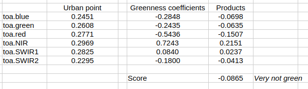

## Scoring a Diegan CSS point

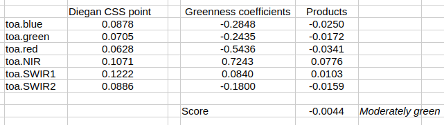

## Scoring a Chaparral point

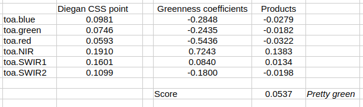

Repeat for each point in the data set

## Compare the greenness between cover types

```
Analysis of Variance Table

Response: Greenness
                   Df  Sum Sq   Mean Sq F value    Pr(>F)
points.Holland_Ob   3 0.03902 0.0130074  15.348 1.824e-09 ***
Residuals         396 0.33561 0.0008475
---
Signif. codes:  0 ‘***’ 0.001 ‘**’ 0.01 ‘*’ 0.05 ‘.’ 0.1 ‘ ’ 1
```

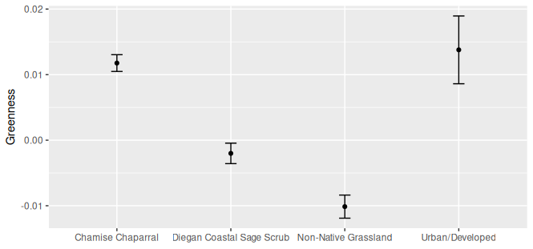

```
 contrast                                           estimate      SE  df t.ratio p.value
 Chamise Chaparral - Diegan Coastal Sage Scrub       0.01378 0.00412 396   3.347  0.0049
 Chamise Chaparral - (Non-Native Grassland)          0.02190 0.00412 396   5.319 <0.0001
 Chamise Chaparral - (Urban/Developed)              -0.00202 0.00412 396  -0.490  0.9614
 Diegan Coastal Sage Scrub - (Non-Native Grassland)  0.00812 0.00412 396   1.973  0.2000
 Diegan Coastal Sage Scrub - (Urban/Developed)      -0.01579 0.00412 396  -3.836  0.0008
 (Non-Native Grassland) - (Urban/Developed)         -0.02392 0.00412 396  -5.809 <0.0001
```

## Kelp anchoring depth

- From Graham 2003, discussing multicollinearity in data analysis
  - Correlations between predictors
  - Can’t tell which is responsible for response
- Response = minimum depth kelp anchored at a site
- Predictors = wave size measures (OD, BD), tide height (LTD), wind (W)

## (A) Solution: PCA predictors

# Summary: PCA

- Very flexible, useful technique
- Exploration:
  - Finding patterns across multiple variables
- Dimensionality reduction
  - Finding fewer, independent axes that represent the data well
- Latent variables
  - Constructing variables that cannot be measured directly